# PA1_template

### 4. Imputing missing values

#### 4.1 Calculate and report the total number of missing values in the dataset (i.e. the total number of rows with NAs)

Review missing values( VALID ? ):

```r
table( ! is.na(activity$steps) )
```

```
##
## FALSE  TRUE
##  2304 15264
```

The FALSE records are the invalid ones.

#### 4.2 Devise a strategy for filling in all of the missing values in the dataset. The strategy does not need to be sophisticated. For example, you could use the mean/median for that day, or the mean for that 5-minute interval, etc.

Create a new objects with “MEAN” (activityConNA) Create a new object with Means (activityPromedio) Review one/one record (activityConNA) and replace data with Means (activityPromedio). I have to obtain the number of records 288 (actitivycantidad), needed to calculate the A/B.

```r
activityConNA    <- activity
activityPromedio <- tapply(activity$steps, activity$interval,mean, na.rm=TRUE)
actitivycantidad <- nrow( activityPromedio )
```

#### 4.3 Create a new dataset that is equal to the original dataset but with the missing data filled in.

```r
for (i in which(is.na(activityConNA)))
    {
    activityConNA[i,1] <- activityPromedio[    ( (i-1) %% actitivycantidad )    +1]
    }
```

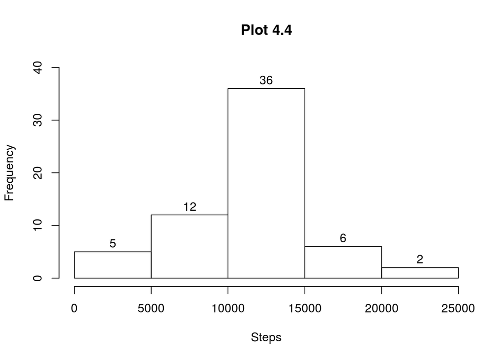

```r
hist( tapply(activityConNA$steps, activityConNA$date,sum), main = "Plot 4.4", xlab="Steps", ylim=c(0,40), labels=T )
```

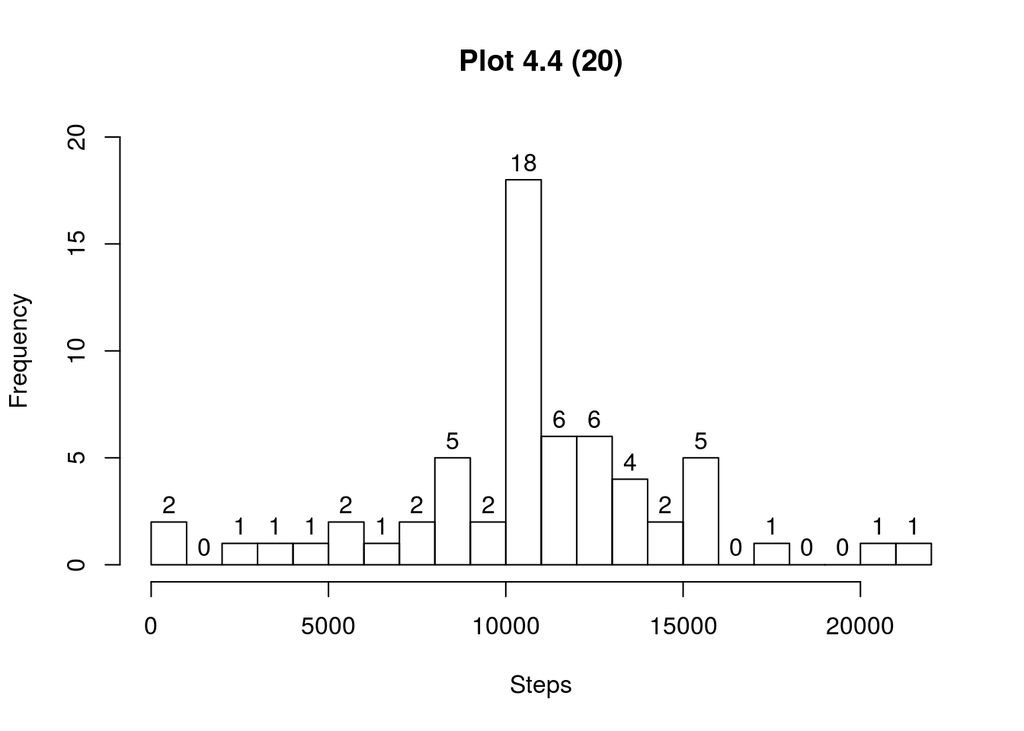

```r
hist( tapply(activityConNA$steps, activityConNA$date,sum), main = "Plot 4.4 (20)", xlab="Steps", ylim=c(0,20), labels=T , breaks=20)
```

### 5. Are there differences in activity patterns between weekdays and weekends?

#### 5.1 Create a new factor variable in the dataset with two levels – “weekday” and “weekend” indicating whether a given date is a weekday or weekend day.

Data with filled in will be used for this point. Calculate DiaSemana (Saturday and Sunday), then prepare a new vector for temporary storage and at the end join original data (activityConNA) with temporary vector (DiaSemana2).

```r
# take care about IDIOM. may be in other languaje will fail. and in lowercase.
DiaSemana  <- c("sabado","domingo","saturday","sunday","sabato", "domenica")

# new vector for calculated data
DiaSemana2 <- c()

# will work with spanish weekend names ?
for (i in 1:length(activityConNA$steps))
    {
    if (any(weekdays(as.Date(activityConNA[i,2])) %in% DiaSemana))
        {
            ##add "weekend"" to new column for that row
            DiaSemana2[i] <- "weekend"  }
            ##else add "weekday"" to new column for that row
        else { DiaSemana2[i] <- "weekday"
         }
}

# add another column with the kind of day, not the best way... but worked.
activityConNA <- cbind(activityConNA,DiaSemana2)
```

#### 5.2 Make a panel plot containing a time series plot (i.e. type = “l”) of the 5-minute interval (x-axis) and the average number of steps taken, averaged across all weekday days or weekend days (y-axis). See the README file in the GitHub repository to see an example of what this plot should look like using simulated data.

```r
# I use Mxxxx as temporary variables in memory
m5     <- split(activityConNA, activityConNA$DiaSemana2)

# d1 to 5, Lunes, martes, miercoles, jueves, viernes
d1a5 <- do.call(rbind.data.frame,m5[1])
d6y7 <- do.call(rbind.data.frame,m5[2])

# average of data, table apply
avgd1a5 <- tapply(d1a5$steps,d1a5$interval,mean)
avgd6y7 <- tapply(d6y7$steps,d6y7$interval,mean)

# build 2 dataframses to prepare data to be plotted
paramd <- as.data.frame(cbind(avgd1a5, as.numeric(  as.character(  names(avgd1a5) ))))
paramw <- as.data.frame(cbind(avgd6y7, as.numeric(  as.character(  names(avgd6y7) ))))

# actitivycantidad = 288.
dfparamd <- cbind(paramd, rep("weekend", actitivycantidad ))
dfparamw <- cbind(paramw, rep("weekday", actitivycantidad ))

# Column names,
colnames(dfparamd) <- c("avgSteps", "interval","dayweek")
colnames(dfparamw) <- c("avgSteps", "interval","dayweek")

AllInOnedata <- rbind(dfparamd, dfparamw)
```

##### Final Plots (2 - comparative weekday vs. weekend)

[figure not shown]